# Project 6 Angelo Rubio

### XGBoost tuned model from undersampled data

```python
%%time
# Defining model
model = XGBClassifier(random_state=1)

# Parameter Grid to pass in RandomizedSearchCV
param_grid={
    'n_estimators': [150, 200, 250],
    'scale_pos_weight': [5,10],
    'learning_rate': [0.1,0.2],
    'gamma': [0,3,5],
    'subsample': [0.8,0.9]
}
#Calling RandomizedSearchCV
randomized_cv_XGB = RandomizedSearchCV(estimator=model, param_distributions=param_grid, n_iter=50, n_jobs = -1, scoring=scorer, cv=5, random_state=1)
#Fitting parameters in RandomizedSearchCV
randomized_cv_XGB.fit(X_train_un,y_train_un)

print("Best parameters are {} with CV score={}:" .format(randomized_cv_XGB.best_params_,randomized_cv_XGB.best_score_))
```

```
Best parameters are {'subsample': 0.8, 'scale_pos_weight': 10, 'n_estimators': 200, 'learning_rate': 0.1, 'gamma': 5} with CV score=0.9269965703086724:
CPU times: user 1.21 s, sys: 287 ms, total: 1.49 s
Wall time: 6.59 s
```

```python
# create pipeline
tuned_XGB = XGBClassifier(
    subsample=0.8, scale_pos_weight=10, n_estimators=200, learning_rate=0.1, gamma=5, random_state=1
)

tuned_XGB.fit(X_train_un, y_train_un)
```

```
XGBClassifier(base_score=None, booster=None, callbacks=None,
              colsample_bylevel=None, colsample_bynode=None,
              colsample_bytree=None, device=None, early_stopping_rounds=None,
              enable_categorical=False, eval_metric=None, feature_types=None,
              gamma=5, grow_policy=None, importance_type=None,
              interaction_constraints=None, learning_rate=0.1, max_bin=None,
              max_cat_threshold=None, max_cat_to_onehot=None,
              max_delta_step=None, max_depth=None, max_leaves=None,
              min_child_weight=None, missing=nan, monotone_constraints=None,
              multi_strategy=None, n_estimators=200, n_jobs=None,
              num_parallel_tree=None, random_state=1, ...)
```

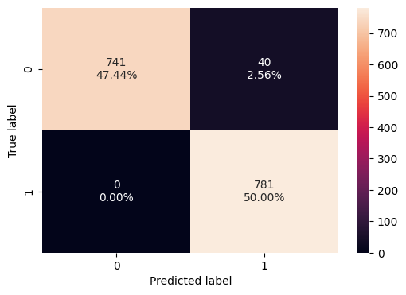

```python
confusion_matrix_sklearn(tuned_XGB, X_train_un, y_train_un)
```

```python
XGB_performance_train = model_performance_classification_sklearn(
    tuned_XGB, X_train_un, y_train_un
)
XGB_performance_train
```

|  | Accuracy | Recall | Precision | F1 |
| --- | --- | --- | --- | --- |
| 0 | 0.974392 | 1.0 | 0.951279 | 0.975031 |

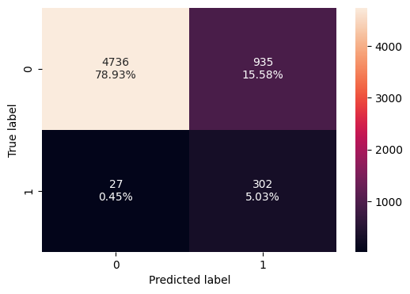

```python
confusion_matrix_sklearn(tuned_XGB, X_val, y_val)
```

```python
XGB_performance_val = model_performance_classification_sklearn(tuned_XGB, X_val, y_val)
XGB_performance_val
```

|  | Accuracy | Recall | Precision | F1 |
| --- | --- | --- | --- | --- |
| 0 | 0.839667 | 0.917933 | 0.244139 | 0.385696 |

### Gradient Boost tuned with undersampled data

```python
%%time
#defining the model
model = GradientBoostingClassifier(random_state=1)

param_grid = {
    "n_estimators": np.arange(100, 150, 25),
    "learning_rate": [0.2, 0.05, 1],
    "subsample": [0.5, 0.7],
    "max_features": [0.5, 0.7],
}

randomized_cv_GBM2 = RandomizedSearchCV(
    estimator=model,
    param_distributions=param_grid,
    n_iter=50,
    scoring=scorer,
    n_jobs=-1,
    cv=5,
    random_state=1,
)

randomized_cv_GBM2.fit(X_train_un, y_train_un)  # Fit the model
print("Best parameters are {} with CV score={}:" .format(randomized_cv_GBM2.best_params_,randomized_cv_GBM2.best_score_))
```

```
Best parameters are {'subsample': 0.7, 'n_estimators': 125, 'max_features': 0.7, 'learning_rate': 0.2} with CV score=0.8962600032663726:
CPU times: user 1.05 s, sys: 94.3 ms, total: 1.14 s
Wall time: 7.39 s
```

```python
#create pipeline
tuned_GBM2 = GradientBoostingClassifier(random_state =1, subsample=0.7, n_estimators=125, max_features=0.7, learning_rate=0.2)
tuned_GBM2.fit(X_train_un, y_train_un)  # Fit the model
```

```
GradientBoostingClassifier(learning_rate=0.2, max_features=0.7,
                           n_estimators=125, random_state=1, subsample=0.7)
```

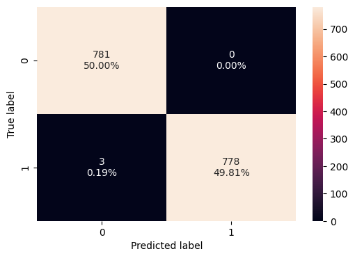

```python
confusion_matrix_sklearn(tuned_GBM2, X_train_un, y_train_un)
```

```python
GBM2_performance_train = model_performance_classification_sklearn(
    tuned_GBM2, X_train_un, y_train_un
)
GBM2_performance_train
```

|  | Accuracy | Recall | Precision | F1 |
| --- | --- | --- | --- | --- |
| 0 | 0.998079 | 0.996159 | 1.0 | 0.998076 |

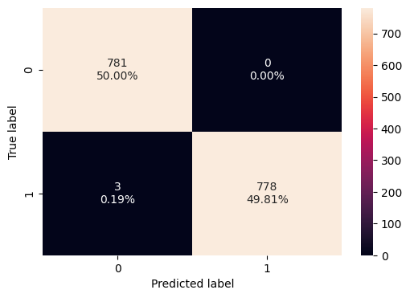

```python
confusion_matrix_sklearn(tuned_GBM2, X_train_un, y_train_un)
```

```python
GBM2_performance_val = model_performance_classification_sklearn(
    tuned_GBM2, X_val, y_val
)
GBM2_performance_val
```

|  | Accuracy | Recall | Precision | F1 |
| --- | --- | --- | --- | --- |
| 0 | 0.945833 | 0.890578 | 0.503436 | 0.643249 |

### Random Forest tuned model from undersampled data

```python
%%time
# Defining model
model = RandomForestClassifier(random_state=1)

#Parameter Grid to pass in RandomizedSearchCV
param_grid = {
    "n_estimators": [200,250,300],
    "min_samples_leaf": np.arange(1, 4),
    "max_features": [np.arange(0.3, 0.6, 0.1),'sqrt'],
    "max_samples": np.arange(0.4, 0.7, 0.1)
}

#Calling RandomizedSearchCV
randomized_cv_Rf = RandomizedSearchCV(estimator=model, param_distributions=param_grid, n_iter=50, n_jobs = -1, scoring=scorer, cv=5, random_state=1)
#Fitting parameters in RandomizedSearchCV
randomized_cv_Rf.fit(X_train_un,y_train_un)

print("Best parameters are {} with CV score={}:" .format(randomized_cv_Rf.best_params_,randomized_cv_Rf.best_score_))
```

```
Best parameters are {'n_estimators': 250, 'min_samples_leaf': 3, 'max_samples': 0.6, 'max_features': 'sqrt'} with CV score=0.8924220153519518:
CPU times: user 1.01 s, sys: 63.2 ms, total: 1.08 s
Wall time: 8.5 s
```

```python
# Create pipeline
tuned_RF = RandomForestClassifier(
    n_estimators=250, min_samples_leaf=3, max_samples=0.6, max_features="sqrt", random_state=1
)
# Fit the model
tuned_RF.fit(X_train_un, y_train_un)
```

```
RandomForestClassifier(max_samples=0.6, min_samples_leaf=3, n_estimators=250,
                       random_state=1)
```

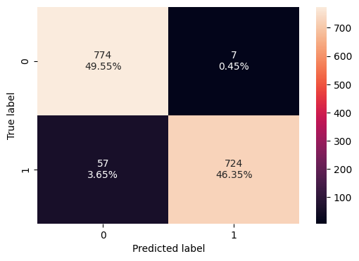

```python
confusion_matrix_sklearn(tuned_RF, X_train_un, y_train_un)
```

```python
RF_performance_train = model_performance_classification_sklearn(
    tuned_RF, X_train_un, y_train_un
)
RF_performance_train
```

|  | Accuracy | Recall | Precision | F1 |
| --- | --- | --- | --- | --- |
| 0 | 0.959027 | 0.927017 | 0.990424 | 0.957672 |

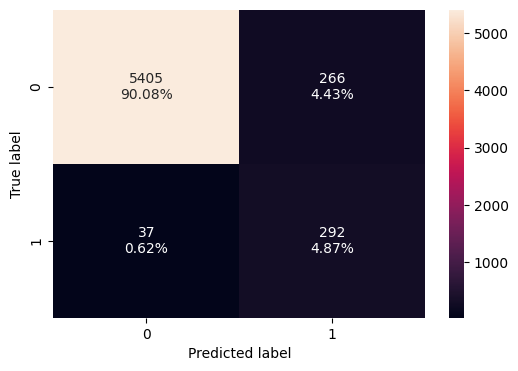

```python
confusion_matrix_sklearn(tuned_RF, X_val, y_val)
```

```python
RF_performance_val = model_performance_classification_sklearn(
    tuned_RF, X_val, y_val
)
RF_performance_val
```

|  | Accuracy | Recall | Precision | F1 |
| --- | --- | --- | --- | --- |
| 0 | 0.9495 | 0.887538 | 0.523297 | 0.658399 |

## Model performance comparison and choosing the final model

```python
# Training performance of the models

model_train_performance = pd.concat(
    [GBM1_performance_train, XGB_performance_train, GBM2_performance_train, RF_performance_train],
    axis=0,
)
model_train_performance["Data"] = ["GBM Oversampled", "XGB Undersampled","GBM Undersampled", "RM Undersampled"]
model_train_performance = model_train_performance.set_index("Data")
model_train_performance
```

| Data | Accuracy | Recall | Precision | F1 |
| --- | --- | --- | --- | --- |
| GBM Oversampled | 0.981806 | 0.979121 | 0.984408 | 0.981757 |
| XGB Undersampled | 0.974392 | 1.000000 | 0.951279 | 0.975031 |
| GBM Undersampled | 0.998079 | 0.996159 | 1.000000 | 0.998076 |
| RM Undersampled | 0.959027 | 0.927017 | 0.990424 | 0.957672 |

We can see that most of the models tend to overfit easily with this data. We need to check the summary of the validation results,

```python
# Validation performance of the models
model_val_performance = pd.concat(
    [GBM1_performance_val, XGB_performance_val, GBM2_performance_val, RF_performance_val],
    axis=0,
)
model_val_performance["Data"] = ["GBM Oversampled", "XGB Undersampled","GBM Undersampled", "RM Undersampled"]
model_val_performance = model_val_performance.set_index("Data")
model_val_performance
```

| Data | Accuracy | Recall | Precision | F1 |
| --- | --- | --- | --- | --- |
| GBM Oversampled | 0.961500 | 0.848024 | 0.606522 | 0.707224 |
| XGB Undersampled | 0.839667 | 0.917933 | 0.244139 | 0.385696 |
| GBM Undersampled | 0.945833 | 0.890578 | 0.503436 | 0.643249 |
| RM Undersampled | 0.949500 | 0.887538 | 0.523297 | 0.658399 |

Based on these results, the model that optimize the recall better is the XGB Undersampled. This is the model we will use for our final model. We have pretty low values on precision (and consequently on F1) because the only metric we are trying to optimize is the recall, to avoid all the false negative results.

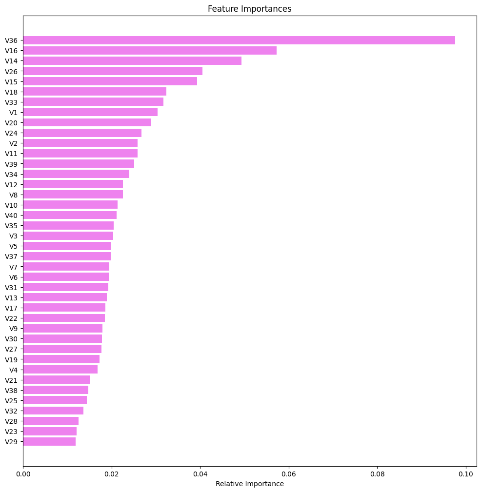

```python
feature_names = X.columns
importances = tuned_XGB.feature_importances_
indices = np.argsort(importances)

plt.figure(figsize=(12, 12))
plt.title("Feature Importances")
plt.barh(range(len(indices)), importances[indices], color="violet", align="center")
plt.yticks(range(len(indices)), [feature_names[i] for i in indices])
plt.xlabel("Relative Importance")
plt.show()
```

### Test set final performance

```python
# Checking the performance of the model on the test data
model_performance_test = model_performance_classification_sklearn(tuned_XGB, X_test, y_test)
model_performance_test
```

|  | Accuracy | Recall | Precision | F1 |
| --- | --- | --- | --- | --- |
| 0 | 0.8508 | 0.882979 | 0.258836 | 0.400322 |